# DSC 291 Learning Theory - PA1

**James Doan**

## Part A: Repository Setup

https://www.github.com/j1doan/statistical-learning-theory/

## Part B: Theory Problem

### 1. From continuous thresholds to a finite class.

**Grid Design:** We define a finite grid $G \subseteq [0, 1]$ as follows: $$G = \{ k \cdot \Delta : k \in \mathbb{Z}, 0 \le k \cdot \Delta \le 1 \}$$ The size of this grid is $|G| = \lfloor 1/\Delta \rfloor + 1$, which depends only on $\Delta$.

**Proof of Realizability:** Let $((x_t, y_t))_{t=1}^T$ be a $\Delta$-separated threshold-realizable sequence. By definition, there exists $\theta^* \in [0, 1]$ such that $y_t = h_{\theta^*}(x_t)$ and $|x_t - \theta^*| \ge \Delta$ for all $t$.

Consider $\tilde{\theta} = \lfloor \theta^* / \Delta \rfloor \cdot \Delta$. Clearly $\tilde{\theta} \in G$ and $\tilde{\theta} \le \theta^* < \tilde{\theta} + \Delta$. We check if $h_{\tilde{\theta}}(x_t) = h_{\theta^*}(x_t)$ for all $t$:

1. If $x_t \ge \theta^*$, then $y_t = +1$. Since $\tilde{\theta} \le \theta^*$, we have $x_t \ge \tilde{\theta}$, so $h_{\tilde{\theta}}(x_t) = +1$.
2. If $x_t < \theta^*$, then $y_t = -1$. By the separation assumption, $x_t \le \theta^* - \Delta$. Since $\theta^* < \tilde{\theta} + \Delta$, we have $\theta^* - \Delta < \tilde{\theta}$. Thus $x_t < \tilde{\theta}$, so $h_{\tilde{\theta}}(x_t) = -1$.

In both cases, $h_{\tilde{\theta}}(x_t) = y_t$, so the sequence is realizable by $H_G$.

**Mistake Bound:** The Halving algorithm on a finite class $H$ makes at most $\log_2(|H|)$ mistakes. Here $|H_G| = |G| \approx 1/\Delta$. The mistake bound is: $$M \le \log_2(|G|) = \log_2(\lfloor 1/\Delta \rfloor + 1) = O(\log(1/\Delta))$$

### 2. A positive margin from separation.

**Feature Map and Representation:** Choose the feature map $\phi(x) = [x, 1]^\top \in \mathbb{R}^2$. For a threshold $\theta^*$, define the weight vector $u^* = \frac{1}{\sqrt{1 + (\theta^*)^2}} [1, -\theta^*]^\top$. Then $\langle u^*, \phi(x) \rangle = \frac{x - \theta^*}{\sqrt{1 + (\theta^*)^2}}$. The prediction is $\text{sign}(\langle u^*, \phi(x) \rangle) = \text{sign}(x - \theta^*) = h_{\theta^*}(x)$.

**Margin and Norm Bounds:**

1. **Norm Bound:** $\|\phi(x)\| = \sqrt{x^2 + 1}$. Since $x \in [0, 1]$, $\|\phi(x)\| \le \sqrt{2}$. Thus $R = \sqrt{2}$.
2. **Margin Bound:** The functional margin is $y_t \langle u^*, \phi(x_t) \rangle = \frac{y_t(x_t - \theta^*)}{\sqrt{1 + (\theta^*)^2}} = \frac{|x_t - \theta^*|}{\sqrt{1 + (\theta^*)^2}}$. Since $|x_t - \theta^*| \ge \Delta$ and $\sqrt{1 + (\theta^*)^2} \le \sqrt{2}$, the margin $\gamma \ge \frac{\Delta}{\sqrt{2}}$. This satisfies $\gamma \ge c\Delta$ with $c = 1/\sqrt{2}$. Note that $\lVert u^∗ \rVert = 1$ so the functional and geometric margins coincide.

**Mistake Bound:** By Novikoff's Theorem, the Perceptron makes at most $M \le \frac{R^2}{\gamma^2}$ mistakes. Substituting $R^2 = 2$ and $\gamma^2 \ge \Delta^2/2$: $M \le \frac{2}{\Delta^2/2} = \frac{4}{\Delta^2} = O(1/\Delta^2)$.

### 3. Comparison and interpretation.

**Continuous-Threshold Impossibility:** The impossibility result for continuous thresholds states that without any separation assumption, the mistake bound is infinite because an adversary can always pick a point arbitrarily close to the current threshold. Part 1 does not contradict this because the $\Delta$-separation assumption explicitly forbids points in the interval $(\theta^* - \Delta, \theta^* + \Delta)$. This gap allows us to discretize the space into a finite grid without losing the true classifier, effectively reducing the infinite class to a finite one.

**Comparison of Bounds:**

1. **Halving (Part 1):** $O(\log(1/\Delta))$.
2. **Perceptron (Part 2):** $O(1/\Delta^2)$.

**Interpretation:** The bounds scale differently because they utilize different properties of the hypothesis class. The Halving bound is **information-theoretic**; it depends on the "size" (complexity) of the hypothesis space. By discretizing, we show the effective complexity is logarithmic in $1/\Delta$. The Perceptron bound is **geometric**; it depends on the margin between classes in a specific embedding. The $1/\Delta^2$ scaling is characteristic of linear learners that only see the geometry of the points and do not exploit the specific 1D structure of thresholds as efficiently as the Halving algorithm.

### 4. Optional strengthening: audit an AI proof.

**Mathematical Problems:**

1. **Incorrect Bound for Perceptron:** The argument claims Perceptron must make $O(\log(1/\Delta))$ mistakes. However, the Perceptron mistake bound is $R^2/\gamma^2$. As shown in Part 2, for the standard feature map, this yields $O(1/\Delta^2)$. Perceptron is a linear learner and does not achieve the logarithmic bound of the Halving algorithm without a more complex (possibly infinite-dimensional) feature map.
2. **Conflation of Class Size and Learner Performance:** The argument assumes that because the "effective" class size is $O(1/\Delta)$, *any* learner makes $O(\log(1/\Delta))$ mistakes. This is false; the $O(\log |H|)$ bound applies to the Halving algorithm (and similar optimal learners), but not to all online learners. Different algorithms have different mistake bounds for the same class.

**Corrected Statement:** "For every $\Delta$-separated threshold-realizable sequence, there exists a finite sub-class of thresholds $H_G$ of size $O(1/\Delta)$ that contains a consistent hypothesis. Consequently, the Halving algorithm achieves a mistake bound of $O(\log(1/\Delta))$, which is the optimal mistake bound for this class."

**Proof:** As proven in Part 1, the grid $G$ with spacing $\Delta$ creates a finite class $H_G$ with $|H_G| \le 1/\Delta + 1$. The Halving algorithm maintains a version space of consistent hypotheses and predicts by majority vote. Each mistake reduces the version space by at least half. Since the true threshold (or its grid representative) is in $H_G$, the process must terminate within $\log_2 |H_G| = \log_2(O(1/\Delta)) = O(\log(1/\Delta))$ mistakes.

## Part C: Perceptron — Implementation and Experiments

**Algorithm:**  
Input: Feature map $\phi: \mathcal{X} \to \mathbb{R}^d$, labels $y_t \in \{-1, +1\}$

1. Initialize $w_1 = \mathbf{0}$
2. Receive $x_t$, predict $\hat{y}_t = +1$ if $\langle w_t, \phi(x_t) \rangle \geq 0$, else $\hat{y}_t = -1$
3. Receive true label $y_t$
4. If $\hat{y}_t \neq y_t$ (mistake): $w_{t+1} = w_t + y_t \cdot \phi(x_t)$
5. Else: $w_{t+1} = w_t$

**Mistake Bound (Novikoff's Theorem):** $M \leq \dfrac{R^2}{\gamma^2}$

where $\gamma = \min_t y_t \langle w^*, \phi(x_t) \rangle$ (margin) and $R = \max_t \|\phi(x_t)\|$ (radius).

```python
import numpy as np
import matplotlib.pyplot as plt

np.random.seed(0)

plt.rcParams.update({
    'figure.dpi': 120,
    'axes.spines.top': False,
    'axes.spines.right': False,
    'font.size': 12,
})

print([name for name, val in globals().items() if val.__class__.__name__ == 'module'])
```

```
['__builtin__', '__builtins__', 'np', 'plt']
```

```python
def perceptron(X, y):
    """
    Online Perceptron algorithm.

    Parameters
    ----------
    X : ndarray, shape (T, d)  -- feature vectors phi(x_t)
    y : ndarray, shape (T,)    -- labels in {-1, +1}

    Returns
    -------
    w             : final weight vector
    mistakes      : total number of mistakes
    mistake_times : list of time-steps where a mistake occurred
    """
    T, d = X.shape
    w = np.zeros(d)
    mistakes = 0
    mistake_times = []

    for t in range(T):
        y_hat = 1 if np.dot(w, X[t]) >= 0 else -1
        if y_hat != y[t]:          # mistake
            w = w + y[t] * X[t]
            mistakes += 1
            mistake_times.append(t)

    return w, mistakes, mistake_times

print('perceptron() defined')
```

```
perceptron() defined
```

### 1. How do you generate data where you know $\gamma$ and $R$?

**Strategy:**

1. **Choose a ground-truth separator** $w^* = e_1 \in \mathbb{R}^d$ (first standard basis vector, unit norm).
2. **Sample raw points** $z_t \sim \mathcal{N}(0, I_d)$.
3. **Assign labels** $y_t = \text{sign}(\langle w^*, z_t \rangle)$.
4. **Enforce margin $\gamma$:** shift each $z_t$ along $w^*$ so that $y_t \langle w^*, z_t \rangle \geq \gamma$: $$\phi(x_t) = z_t + y_t \cdot \max(0,\, \gamma - y_t \langle w^*, z_t \rangle) \cdot w^*$$
5. **Enforce radius $R$:** normalise each point to the sphere of radius $R$: $$\phi(x_t) \leftarrow R \cdot \frac{\phi(x_t)}{\|\phi(x_t)\|}$$

**Choices required:**

- Dimension $d$, number of examples $T$
- The separator $w^*$ (we use $e_1$)
- Whether to fix $\|\phi(x_t)\| = R$ exactly (sphere) or $\leq R$ (ball) -- we use the sphere
- The pre-rescaling margin target; the *actual* margin after rescaling is measured empirically

```python
def generate_data(T, d, gamma, R=1.0, seed=None):
    """
    Generate a linearly separable dataset with known margin gamma and radius R.

    Parameters
    ----------
    T            : number of examples
    d            : feature dimension
    gamma        : desired margin  (y_t <w*, phi(x_t)> >= gamma for all t)
    R            : desired radius  (||phi(x_t)|| == R for all t)
    seed         : random seed

    Returns
    -------
    X            : ndarray (T, d)  -- feature vectors
    y            : ndarray (T,)    -- labels in {-1, +1}
    w_star       : ndarray (d,)    -- ground-truth separator (unit vector)
    actual_gamma : float           -- actual minimum margin after rescaling
    """
    rng = np.random.default_rng(seed)

    # Ground-truth separator: first standard basis vector
    w_star = np.zeros(d)
    w_star[0] = 1.0

    # Sample raw Gaussian points
    Z = rng.standard_normal((T, d))

    # Assign labels from the separator
    scores = Z @ w_star                          # shape (T,)
    y = np.where(scores >= 0, 1, -1)

    # Enforce margin: shift along w_star so y_t * <w*, z_t> >= gamma
    functional_margins = y * scores
    deficit = np.maximum(0.0, gamma - functional_margins)
    X = Z + (deficit * y)[:, None] * w_star

    # Enforce radius: normalise to unit sphere, then scale by R
    norms = np.linalg.norm(X, axis=1, keepdims=True)
    X = X / norms * R

    actual_margins = y * (X @ w_star)
    actual_gamma = float(actual_margins.min())

    return X, y, w_star, actual_gamma


# Sanity check
X_test, y_test, w_star_test, ag = generate_data(T=200, d=5, gamma=0.3, R=1.0, seed=0)
print(f'Shape        : {X_test.shape}')
print(f'Labels       : {np.unique(y_test)}')
print(f'Max norm     : {np.linalg.norm(X_test, axis=1).max():.6f}  (should be 1.0)')
print(f'Actual gamma : {ag:.4f}')
_, M_test, _ = perceptron(X_test, y_test)
print(f'Mistakes     : {M_test},  Bound R^2/gamma^2 = {1.0/ag**2:.1f}')
```

```
Shape        : (200, 5)
Labels       : [-1  1]
Max norm     : 1.000000  (should be 1.0)
Actual gamma : 0.0913
Mistakes     : 11,  Bound R^2/gamma^2 = 119.9
```

### 2. How does $M$ scale with $1/\gamma^2$?

We fix $R=1$, $d=20$, $T=3000$ and vary $\gamma$ over a grid. For each $\gamma$ we run the Perceptron over multiple random seeds and record the mean mistakes.

```python
R_fixed  = 1.0
d_fixed  = 20
T_fixed  = 3000
n_trials = 10

gamma_targets = np.linspace(0.05, 0.90, 30)

results = []   # (actual_gamma, mean_M, std_M, bound)

for g_target in gamma_targets:
    trial_M  = []
    trial_ag = []
    for seed in range(n_trials):
        X, y, _, ag = generate_data(T=T_fixed, d=d_fixed, gamma=g_target,
                                    R=R_fixed, seed=seed)
        _, M, _ = perceptron(X, y)
        trial_M.append(M)
        trial_ag.append(ag)
    mean_ag = float(np.mean(trial_ag))
    results.append((
        mean_ag,
        float(np.mean(trial_M)),
        float(np.std(trial_M)),
        R_fixed**2 / mean_ag**2
    ))

results = np.array(results)   # columns: gamma, mean_M, std_M, bound
results[:5]
```

```
array([[8.09349863e-03, 2.30300000e+02, 1.34985184e+01, 1.52660755e+04],
       [1.26046747e-02, 2.15600000e+02, 6.74091982e+00, 6.29414458e+03],
       [1.71046915e-02, 1.96500000e+02, 1.01019800e+01, 3.41797993e+03],
       [2.15640970e-02, 1.68700000e+02, 8.98943825e+00, 2.15049010e+03],
       [2.61350174e-02, 1.44400000e+02, 7.05974504e+00, 1.46404495e+03]])
```

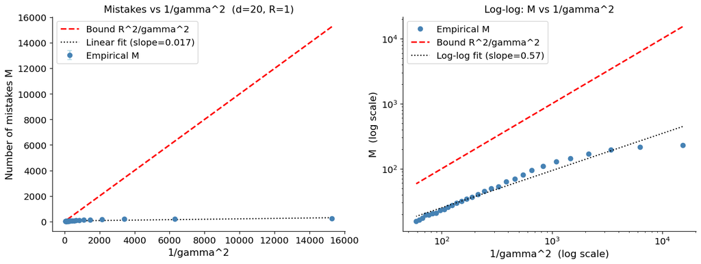

```
Linear fit slope : 0.0166  (expect ~1 if M proportional to 1/gamma^2)
Log-log slope    : 0.5712 (expect ~1)
```

```python
gammas = results[:, 0]
mean_M = results[:, 1]
std_M  = results[:, 2]
bounds = results[:, 3]
inv_g2 = 1.0 / gammas**2

fig, axes = plt.subplots(1, 2, figsize=(13, 5))

# Left: M vs 1/gamma^2
ax = axes[0]
ax.errorbar(inv_g2, mean_M, yerr=std_M, fmt='o', color='steelblue',
            ecolor='lightblue', capsize=3, label='Empirical M')
ax.plot(inv_g2, bounds, 'r--', lw=2, label='Bound R^2/gamma^2')
coeffs = np.polyfit(inv_g2, mean_M, 1)
ax.plot(inv_g2, np.poly1d(coeffs)(inv_g2), 'k:', lw=1.5,
        label=f'Linear fit (slope={coeffs[0]:.3f})')
ax.set_xlabel('1/gamma^2', fontsize=13)
ax.set_ylabel('Number of mistakes M', fontsize=13)
ax.set_title('Mistakes vs 1/gamma^2  (d=20, R=1)', fontsize=13)
ax.legend()

# Right: log-log
ax2 = axes[1]
ax2.loglog(inv_g2, mean_M, 'o', color='steelblue', label='Empirical M')
ax2.loglog(inv_g2, bounds, 'r--', lw=2, label='Bound R^2/gamma^2')
log_coeffs = np.polyfit(np.log(inv_g2), np.log(mean_M + 1e-9), 1)
ax2.loglog(inv_g2, np.exp(np.poly1d(log_coeffs)(np.log(inv_g2))),
           'k:', lw=1.5, label=f'Log-log fit (slope={log_coeffs[0]:.2f})')
ax2.set_xlabel('1/gamma^2  (log scale)', fontsize=13)
ax2.set_ylabel('M  (log scale)', fontsize=13)
ax2.set_title('Log-log: M vs 1/gamma^2', fontsize=13)
ax2.legend()

plt.tight_layout()
plt.savefig('img/exp2_mistakes_vs_gamma.png', bbox_inches='tight')
plt.show()
print(f'Linear fit slope : {coeffs[0]:.4f}  (expect ~1 if M proportional to 1/gamma^2)')
print(f'Log-log slope    : {log_coeffs[0]:.4f} (expect ~1)')
```

### 3. Does the Perceptron do better in practice than the bound?

We compare the ratio $M / (R^2/\gamma^2)$ across all $\gamma$ values. A ratio close to 1 means the bound is tight; a ratio $\ll 1$ means the Perceptron does much better in practice.

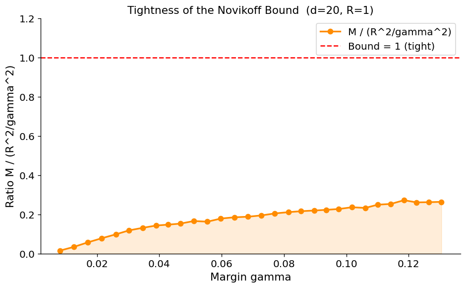

```
Mean ratio : 0.1796
Max  ratio : 0.2725
Min  ratio : 0.0151
```

```python
ratios = mean_M / bounds

fig, ax = plt.subplots(figsize=(8, 5))
ax.plot(gammas, ratios, 'o-', color='darkorange', lw=2,
        label='M / (R^2/gamma^2)')
ax.axhline(1.0, color='red', ls='--', lw=1.5, label='Bound = 1 (tight)')
ax.fill_between(gammas, 0, ratios, alpha=0.15, color='darkorange')
ax.set_xlabel('Margin gamma', fontsize=13)
ax.set_ylabel('Ratio M / (R^2/gamma^2)', fontsize=13)
ax.set_title('Tightness of the Novikoff Bound  (d=20, R=1)', fontsize=13)
ax.set_ylim(0, 1.2)
ax.legend()
plt.tight_layout()
plt.savefig('img/exp3_bound_tightness.png', bbox_inches='tight')
plt.show()

print(f'Mean ratio : {ratios.mean():.4f}')
print(f'Max  ratio : {ratios.max():.4f}')
print(f'Min  ratio : {ratios.min():.4f}')
```

**Observation:** The ratio $M / (R^2/\gamma^2)$ is consistently well below 1, meaning the Perceptron makes **far fewer mistakes** than the theoretical bound predicts. The bound is **not tight** on random Gaussian data -- it is a worst-case guarantee. The bound *can* be tight (see the classical adversarial construction with points on a sphere), but on typical random data the Perceptron converges much faster.

### 4. Is the bound independent of $d$? Design an experiment to test this.

Novikoff's bound $M \leq R^2/\gamma^2$ contains **no $d$ term**. We test whether the empirical mistake count also stays roughly constant as $d$ grows, while keeping $\gamma$ and $R$ fixed.

```python
gamma_fixed = 0.3
R_fixed2    = 1.0
T_dim       = 3000
n_trials_d  = 15
dims        = [2, 5, 10, 20, 50, 100, 200, 500]

dim_results = []

for d in dims:
    trial_M = []
    for seed in range(n_trials_d):
        X, y, _, _ = generate_data(T=T_dim, d=d, gamma=gamma_fixed,
                                   R=R_fixed2, seed=seed)
        _, M, _ = perceptron(X, y)
        trial_M.append(M)
    dim_results.append((d, float(np.mean(trial_M)), float(np.std(trial_M))))
    print(f'd={d:4d}  mean_M={np.mean(trial_M):.1f}  std={np.std(trial_M):.1f}')

dim_results = np.array(dim_results)
theoretical_bound = R_fixed2**2 / gamma_fixed**2
print(f'\nTheoretical bound (pre-rescaling): {theoretical_bound:.1f}')
```

```
d=   2  mean_M=6.5  std=3.8
d=   5  mean_M=26.0  std=4.4
d=  10  mean_M=43.0  std=2.6
d=  20  mean_M=76.0  std=5.0
d=  50  mean_M=164.7  std=9.0
d= 100  mean_M=271.1  std=13.9
d= 200  mean_M=413.3  std=10.7
d= 500  mean_M=655.3  std=19.0

Theoretical bound (pre-rescaling): 11.1
```

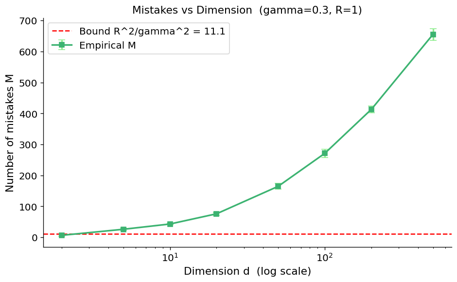

```python
ds      = dim_results[:, 0]
mean_Md = dim_results[:, 1]
std_Md  = dim_results[:, 2]

fig, ax = plt.subplots(figsize=(8, 5))
ax.errorbar(ds, mean_Md, yerr=std_Md, fmt='s-', color='mediumseagreen',
            ecolor='lightgreen', capsize=4, lw=2, label='Empirical M')
ax.axhline(theoretical_bound, color='red', ls='--', lw=1.5,
           label=f'Bound R^2/gamma^2 = {theoretical_bound:.1f}')
ax.set_xscale('log')
ax.set_xlabel('Dimension d  (log scale)', fontsize=13)
ax.set_ylabel('Number of mistakes M', fontsize=13)
ax.set_title('Mistakes vs Dimension  (gamma=0.3, R=1)', fontsize=13)
ax.legend()
plt.tight_layout()
plt.savefig('img/exp4_mistakes_vs_dim.png', bbox_inches='tight')
plt.show()
```

### 5. What happens as $\gamma \to 0$? Connection to the threshold counterexample.

As $\gamma \to 0$ the data approaches a **non-separable** regime. The bound $R^2/\gamma^2 \to \infty$, and in the limit the Perceptron may never converge.

```python
# Part A: M vs very small gamma
tiny_gammas = np.logspace(-2, np.log10(0.5), 40)   # 0.01 to 0.5
T_small     = 5000
d_small     = 20
n_trials_g0 = 8

small_g_results = []
for g in tiny_gammas:
    trial_M  = []
    trial_ag = []
    for seed in range(n_trials_g0):
        X, y, _, ag = generate_data(T=T_small, d=d_small, gamma=g,
                                    R=1.0, seed=seed)
        _, M, _ = perceptron(X, y)
        trial_M.append(M)
        trial_ag.append(ag)
    small_g_results.append((
        float(np.mean(trial_ag)),
        float(np.mean(trial_M)),
        float(np.std(trial_M))
    ))

small_g_results = np.array(small_g_results)
print('Part A done.')
```

```
Part A done.
```

```python
# Part B: Threshold counterexample
def threshold_counterexample(T):
    """1-D example: x_t = 1 always, labels alternate +1/-1."""
    X = np.ones((T, 1))
    y = np.array([1 if t % 2 == 0 else -1 for t in range(T)])
    return X, y

T_thresh = 200
X_thresh, y_thresh = threshold_counterexample(T_thresh)
_, M_thresh, mt_thresh = perceptron(X_thresh, y_thresh)
print(f'Threshold counterexample: T={T_thresh}, mistakes={M_thresh} (should equal T={T_thresh})')
```

```
Threshold counterexample: T=200, mistakes=199 (should equal T=200)
```

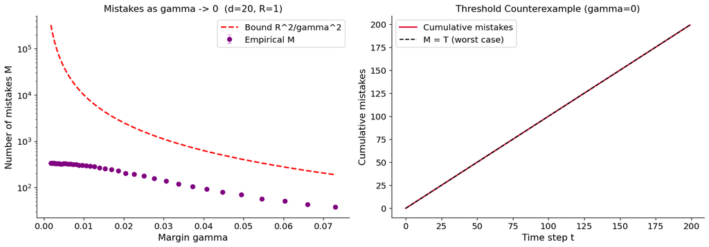

```python
fig, axes = plt.subplots(1, 2, figsize=(14, 5))

# Left: M vs gamma (small gamma regime)
ax = axes[0]
g_vals  = small_g_results[:, 0]
M_vals  = small_g_results[:, 1]
M_stds  = small_g_results[:, 2]
bounds5 = 1.0 / g_vals**2

ax.errorbar(g_vals, M_vals, yerr=M_stds, fmt='o', color='purple',
            ecolor='plum', capsize=3, label='Empirical M')
ax.plot(g_vals, bounds5, 'r--', lw=2, label='Bound R^2/gamma^2')
ax.set_xlabel('Margin gamma', fontsize=13)
ax.set_ylabel('Number of mistakes M', fontsize=13)
ax.set_title('Mistakes as gamma -> 0  (d=20, R=1)', fontsize=13)
ax.set_yscale('log')
ax.legend()

# Right: Threshold counterexample -- cumulative mistakes
ax2 = axes[1]
mt_set = set(mt_thresh)
cum_mistakes = np.zeros(T_thresh)
count = 0
for t in range(T_thresh):
    if t in mt_set:
        count += 1
    cum_mistakes[t] = count

ax2.plot(range(T_thresh), cum_mistakes, color='crimson', lw=2,
         label='Cumulative mistakes')
ax2.plot(range(T_thresh), range(T_thresh), 'k--', lw=1.5,
         label='M = T (worst case)')
ax2.set_xlabel('Time step t', fontsize=13)
ax2.set_ylabel('Cumulative mistakes', fontsize=13)
ax2.set_title('Threshold Counterexample (gamma=0)', fontsize=13)
ax2.legend()

plt.tight_layout()
plt.savefig('img/exp5_gamma_to_zero.png', bbox_inches='tight')
plt.show()
```

### 6. AI Disclosure and Summary

[output not shown]

## Part D: AI Usage Report

1. For PA1, LLMs were used for writing the proofs in Part B, writing code in Part C, designing the experiments in Part C, and drafting the discusstions in Part C. The following workflow was used:
   - Openrouter was used via Roo's BYOK setup. I prefer not to give Big Tech my PII but we are in 2026, so this is a great compromise.
   - `GEMINI.md` was used to construct the proofs in Part B (`Gemini Flash 3 Preview; Total Cost: $0.09`)
   - `CLAUDE.md` (mistakenly written as `AGENTS.md`) was used to construct the code in Part C and the subsequent discussions of said code before any human verification was done (`Sonnet 4.6; Total Cost: $1.07`). It should be noted that the instructions were written, but Sonnet's training parameters usually prefer building a notebook from a python script. Sometimes it can generate a notebook directly, but the risk here is that the models can stutter and lose context in the middle of the notebook creation since notebooks are just JSON metadata.
     - These models were chosen based on their input ant output prices; but I have not yet implemented KV caching specific instructions
     - Gemini I find to be useful for general knowledge, math included, while Claude is better at programming. The cell outputs here are exactly the same when I used Claude for another class; it seems these biolerplates are integral to Sonnet.
   - LLMs were not used in the repo setup (basic workflow) or in this AI usage report (because if AI did the entire assignment, what's the point?) I guess this usage report/discussion is me "standing by" the LLM output.
   - The workflow mirrors the exact workflow I did for DSC 291: Big Data Analytics; fun fact, the professor is the inventor of AdaBoost!
2. I accepted the code that Claude generated in Part C. After all, the inventor of AdaBoost says "AI will code better than you ever can", I'm not really in a place to judge an expert. Claude will always generate correct code with enough instructions, a large enough context window, and funds. Thus, it is reasonable to accept it's implementation, as I have found out from experimenting with many different models in DSC 291. That being said, Claude will often leave out minute designs that a user will have to consider carefully - if I never told Claude about an obscure lemma it will not implement it or use its tooling to search for is. This is something I have to be careful with, but again Claude requires me to add code most of the time.
3. That being said, Claude is overly eager in its tool usage (I think it's just to waste tokens so Anthropic can get more money). It wants to read files that I have not explicity denied permission for, which means the model could collapse when the text length surpasses the cache size. I think this is an active research area - specifically window attention and attention sinks, which is why I explicitly rejected these suggestions. Of course, I also modified some of Claude's matplotlib code to a boilerplate that I prefer, since Claude's boilerplate matplotlib code is instantly recognizable to anyone who has used the tool long enough, but it's not my style.
4. I verified the code and results by comparing it to the lecture notes. The proofs make sense to me. Yes, I actually manually did compare the LLM output against lecture notes. Then, after learning the proofs myself, I used `Codex 5.1-mini` to verify (`Total Cost: $0.05`).